# The imposter syndrome is strong with this one

```r
library(tidyverse)
library(tidymodels)
library(stacks)
dir <- '20210302'
path_coefs_glm <- here::here(dir, 'coefs_glm.rds')
path_res_knn <- here::here(dir, 'res_knn.rds')
path_res_rf <- here::here(dir, 'res_rf.rds')
path_fit_ens <- here::here(dir, 'fit_ens.rds')
path_preds_holdout <- here::here(dir, 'preds_holdout.csv')
path_probs_holdout <- here::here(dir, 'probs_holdout.csv')
df <-
  here::here(dir, 'sliced-s00e01-data.csv') %>%
  read_csv(guess_max = 20000) %>%
  select(-X1)

df_holdout <-
  here::here(dir, 'sliced-s00e01-holdout.csv') %>%
  read_csv()
```

Wow there are a lot of columns. Some of these numeric ones are really categorical features in disguise.

```r
df %>%
  skimr::skim()
```

Data summary

| Name | Piped data |
| --- | --- |
| Number of rows | 5934 |
| Number of columns | 119 |
| _______________________ |  |
| Column type frequency: |  |
| character | 4 |
| numeric | 115 |
| ________________________ |  |
| Group variables | None |

**Variable type: character**

| skim_variable | n_missing | complete_rate | min | max | empty | n_unique | whitespace |
| --- | --- | --- | --- | --- | --- | --- | --- |
| field | 58 | 0.99 | 3 | 51 | 0 | 194 | 0 |
| undergra | 1902 | 0.68 | 2 | 49 | 0 | 213 | 0 |
| from | 74 | 0.99 | 2 | 58 | 0 | 207 | 0 |
| career | 84 | 0.99 | 1 | 77 | 0 | 294 | 0 |

**Variable type: numeric**

| skim_variable | n_missing | complete_rate | mean | sd | p0 | p25 | p50 | p75 | p100 | hist |
| --- | --- | --- | --- | --- | --- | --- | --- | --- | --- | --- |
| iid | 0 | 1.00 | 310.30 | 179.37 | 1.00 | 102.00 | 362.0 | 467.00 | 552.00 | ▇▁▃▇▇ |
| id | 1 | 1.00 | 8.65 | 5.37 | 1.00 | 4.00 | 8.0 | 13.00 | 22.00 | ▇▆▅▃▂ |
| gender | 0 | 1.00 | 0.50 | 0.50 | 0.00 | 0.00 | 1.0 | 1.00 | 1.00 | ▇▁▁▁▇ |
| idg | 0 | 1.00 | 16.68 | 10.65 | 1.00 | 8.00 | 15.0 | 25.00 | 44.00 | ▇▇▅▅▂ |
| condtn | 0 | 1.00 | 1.80 | 0.40 | 1.00 | 2.00 | 2.0 | 2.00 | 2.00 | ▂▁▁▁▇ |
| wave | 0 | 1.00 | 12.25 | 6.85 | 1.00 | 4.00 | 14.0 | 19.00 | 21.00 | ▇▁▃▇▇ |
| round | 0 | 1.00 | 16.24 | 4.44 | 6.00 | 14.00 | 18.0 | 19.00 | 22.00 | ▂▃▃▇▇ |
| position | 0 | 1.00 | 8.77 | 5.40 | 1.00 | 4.00 | 8.0 | 13.00 | 22.00 | ▇▆▅▃▂ |
| positin1 | 1846 | 0.69 | 9.05 | 5.59 | 1.00 | 4.00 | 8.0 | 13.00 | 22.00 | ▇▆▅▃▂ |
| order | 0 | 1.00 | 8.61 | 5.34 | 1.00 | 4.00 | 8.0 | 13.00 | 22.00 | ▇▆▅▃▂ |
| partner | 0 | 1.00 | 8.65 | 5.37 | 1.00 | 4.00 | 8.0 | 13.00 | 22.00 | ▇▆▅▃▂ |
| pid | 10 | 1.00 | 310.61 | 179.36 | 1.00 | 102.00 | 362.0 | 467.00 | 552.00 | ▇▁▃▇▇ |
| match | 0 | 1.00 | 0.17 | 0.37 | 0.00 | 0.00 | 0.0 | 0.00 | 1.00 | ▇▁▁▁▂ |
| int_corr | 148 | 0.98 | 0.19 | 0.30 | -0.73 | -0.03 | 0.2 | 0.42 | 0.91 | ▁▃▇▇▂ |
| samerace | 0 | 1.00 | 0.40 | 0.49 | 0.00 | 0.00 | 0.0 | 1.00 | 1.00 | ▇▁▁▁▅ |
| age_o | 99 | 0.98 | 26.31 | 3.67 | 18.00 | 23.00 | 26.0 | 29.00 | 55.00 | ▇▇▁▁▁ |
| race_o | 68 | 0.99 | 2.80 | 1.25 | 1.00 | 2.00 | 2.0 | 4.00 | 6.00 | ▇▁▃▁▁ |
| pf_o_att | 84 | 0.99 | 24.24 | 13.84 | 2.00 | 15.00 | 20.0 | 30.00 | 100.00 | ▇▅▁▁▁ |
| pf_o_sin | 84 | 0.99 | 17.00 | 7.65 | 0.00 | 10.00 | 20.0 | 20.00 | 60.00 | ▃▇▂▁▁ |
| pf_o_int | 84 | 0.99 | 20.48 | 7.32 | 0.00 | 17.00 | 20.0 | 25.00 | 50.00 | ▂▇▃▁▁ |
| pf_o_fun | 93 | 0.98 | 17.45 | 6.80 | 0.00 | 13.00 | 20.0 | 20.00 | 50.00 | ▃▇▂▁▁ |
| pf_o_amb | 102 | 0.98 | 9.77 | 6.22 | 0.00 | 5.00 | 10.0 | 15.00 | 53.00 | ▇▅▁▁▁ |
| pf_o_sha | 124 | 0.98 | 11.28 | 6.77 | 0.00 | 5.00 | 10.0 | 15.00 | 30.00 | ▇▇▆▅▁ |
| dec_o | 0 | 1.00 | 0.42 | 0.49 | 0.00 | 0.00 | 0.0 | 1.00 | 1.00 | ▇▁▁▁▆ |
| attr_o | 201 | 0.97 | 6.19 | 1.98 | 0.00 | 5.00 | 6.0 | 8.00 | 10.50 | ▁▃▇▇▂ |
| sinc_o | 242 | 0.96 | 7.20 | 1.77 | 0.00 | 6.00 | 7.0 | 8.00 | 10.00 | ▁▁▃▇▃ |
| intel_o | 254 | 0.96 | 7.36 | 1.58 | 0.00 | 6.00 | 7.0 | 8.00 | 10.00 | ▁▁▃▇▃ |
| fun_o | 289 | 0.95 | 6.44 | 1.98 | 0.00 | 5.00 | 7.0 | 8.00 | 11.00 | ▁▂▇▇▃ |
| amb_o | 531 | 0.91 | 6.78 | 1.83 | 0.00 | 6.00 | 7.0 | 8.00 | 10.00 | ▁▁▆▇▃ |
| shar_o | 769 | 0.87 | 5.45 | 2.20 | 0.00 | 4.00 | 6.0 | 7.00 | 10.00 | ▂▃▇▆▂ |

[output cut: 85 more lines]

Correlation eda spared for later…

More futile eda trying to gain some insight

```r
df %>% count(dec_o)
```

```
## # A tibble: 2 x 2
##   dec_o     n
## * <dbl> <int>
## 1     0  3450
## 2     1  2484
```

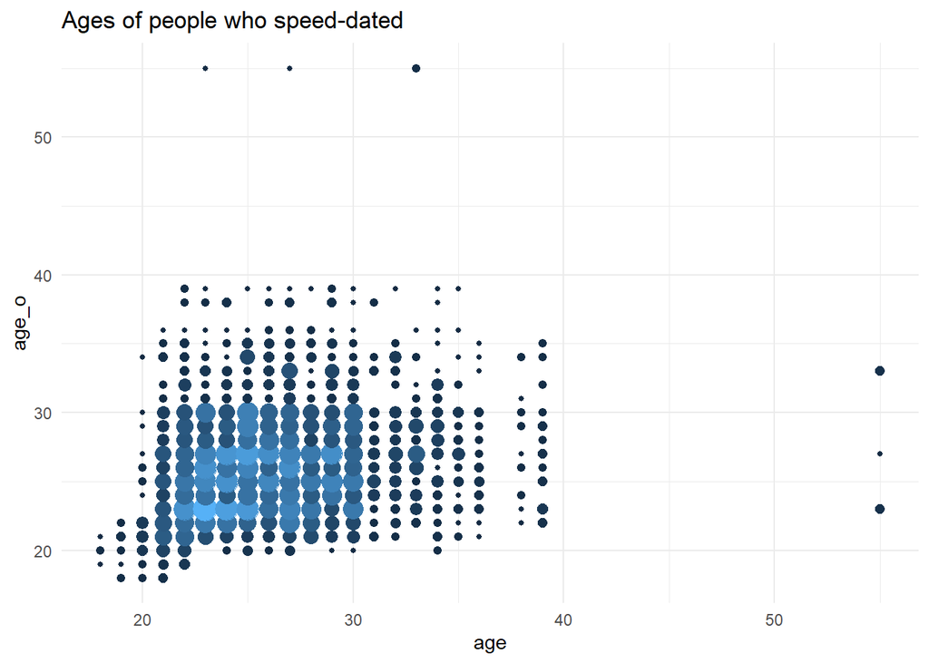

```r
gg_age <-
  df %>%
  group_by(age, age_o) %>%
  summarize(across(dec, sum)) %>%
  ungroup() %>%
  ggplot() +
  aes(x = age, y = age_o) +
  geom_point(aes(size = dec, color = dec)) +
  theme_minimal() +
  labs(title = 'Ages of people who speed-dated') +
  guides(color = FALSE, size = FALSE)
gg_age
```

Logistic regression with every variable, what could go wrong?

```r
f_glm <- function(col_x) {
  fit <- glm(
    formula(glue::glue('match ~ {col_x}')),
    data = df,
    family = 'binomial'
  )
  tidy(fit)
}
col_y <- 'match'
nms <- df %>% names()
cols_x <- nms %>% setdiff(col_y)
cols_x %>% length()
```

```
## [1] 118
```

```r
cols_x_filt <- cols_x %>% str_subset('id$', negate = TRUE)
```

```r
coefs_glm <-
  cols_x_filt %>% map_dfr(f_glm)
```

```r
coefs_glm %>%
  filter(term != '(Intercept)') %>%
  arrange(p.value)
```

```
## # A tibble: 1,015 x 6
##    term   estimate std.error statistic   p.value   idx
##    <chr>     <dbl>     <dbl>     <dbl>     <dbl> <int>
##  1 like      0.560    0.0255      22.0 3.13e-107  1102
##  2 like_o    0.560    0.0255      22.0 3.55e-107    54
##  3 fun       0.460    0.0227      20.2 4.79e- 91  1096
##  4 fun_o     0.460    0.0227      20.2 5.27e- 91    48
##  5 attr      0.417    0.0216      19.3 6.21e- 83  1090
##  6 attr_o    0.417    0.0216      19.3 6.43e- 83    42
##  7 shar      0.382    0.0201      19.0 1.22e- 80  1100
##  8 shar_o    0.382    0.0201      19.0 1.25e- 80    52
##  9 prob      0.358    0.0188      19.0 1.31e- 80  1104
## 10 prob_o    0.358    0.0188      19.0 1.58e- 80    56
## # ... with 1,005 more rows
```

On average, people rated each other around a 5-7.

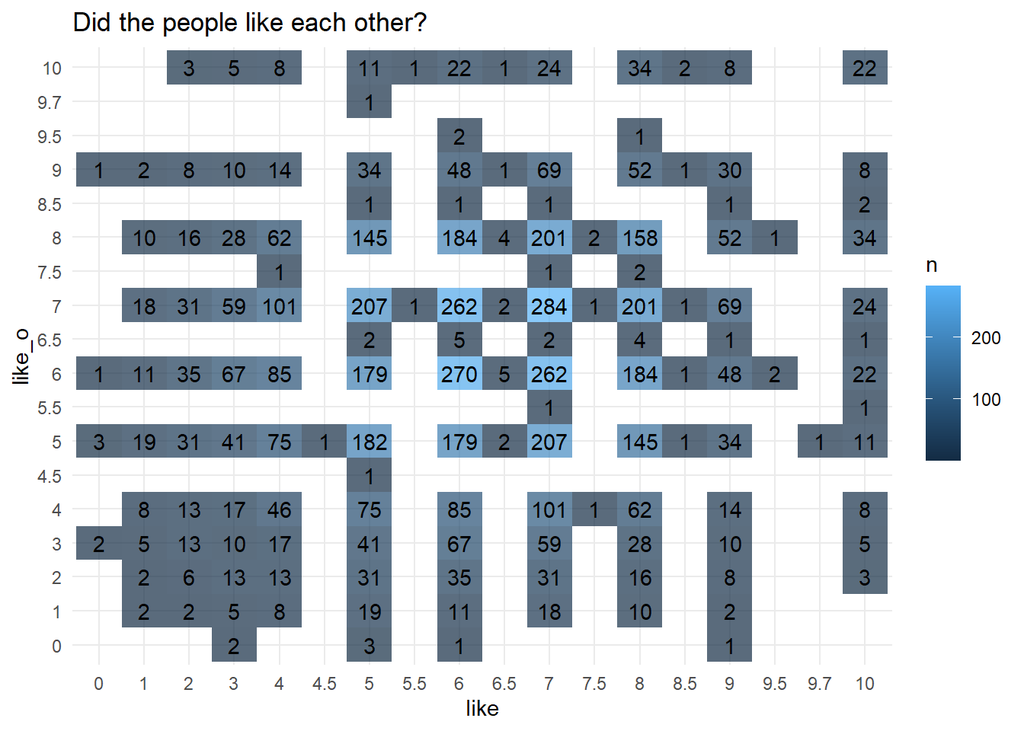

```r
df %>%
  count(like, like_o) %>%
  mutate(across(c(like, like_o), factor)) %>%
  drop_na() %>%
  ggplot() +
  aes(x = like, y = like_o) +
  geom_tile(aes(fill = n), alpha = 0.7) +
  geom_text(aes(label = n)) +
  theme_minimal() +
  labs(
    title = 'Did the people like each other?'
  )
```

We’ve got a ton of the these {attribute} and {attribute}_o (other person) feature pairs. Surely we can do something with them

Note that there is a big class imbalance.

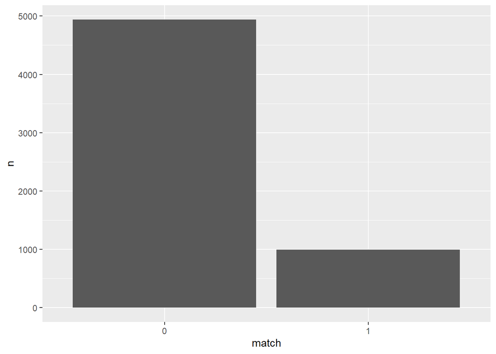

```r
df %>%
  count(match) %>%
  mutate(across(match, factor)) %>%
  ggplot() +
  aes(x = match, y= n) +
  geom_col()
```

There’s variation in the number of people in each wave of speed-dating. Probably not useful for a quick model.

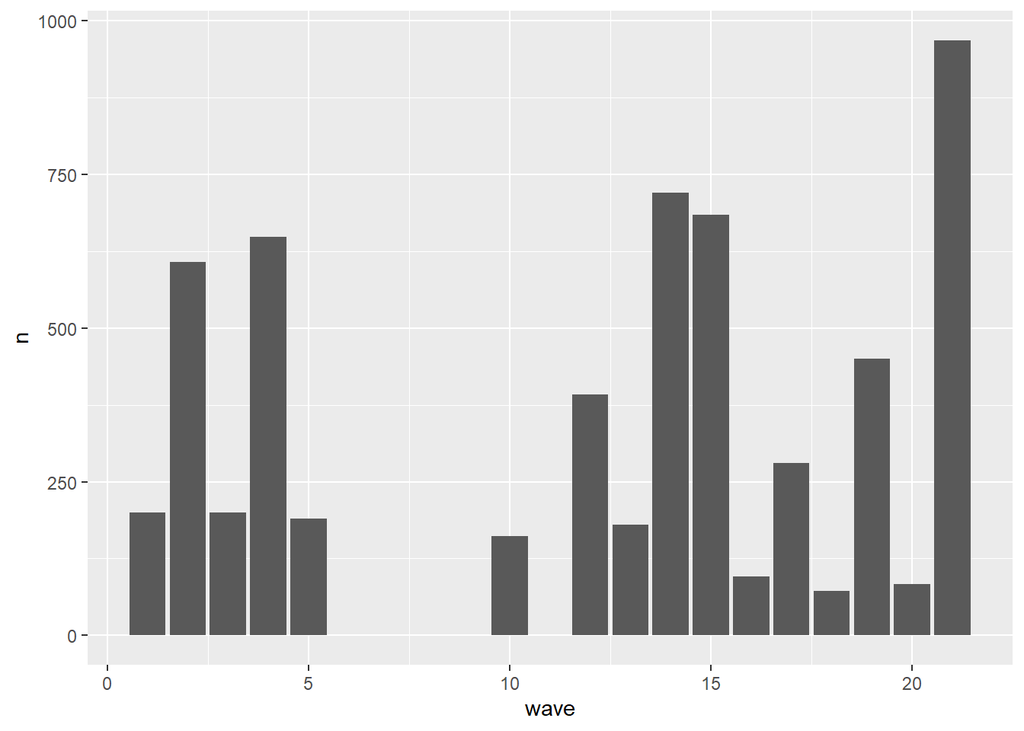

```r
df %>%
  count(wave) %>%
  ggplot() +
  aes(x = wave, y = n) +
  geom_col()
```

I noticed that the p.values were smaller for paired features, and it might just make sense to focus on them.

```r
cols_x_paired <-
  cols_x %>%
  str_remove('_o$') %>%
  tibble(col = .) %>%
  count(col) %>%
  filter(n > 1L) %>%
  filter(col != 'dec')
cols_x_paired
```

```
## # A tibble: 11 x 2
##    col       n
##    <chr> <int>
##  1 age       2
##  2 amb       2
##  3 attr      2
##  4 fun       2
##  5 intel     2
##  6 like      2
##  7 met       2
##  8 prob      2
##  9 race      2
## 10 shar      2
## 11 sinc      2
```

```r
f_select <- function(data) {
  res <-
    data %>%
    select(
    any_of(col_y),
    one_of(cols_x_paired %>% pull(col)),
    one_of(cols_x_paired %>% pull(col) %>% paste0('_o'))
  )

  if(any('match' %in% colnames(res))) {
    res <-
      res %>%
      mutate(across(match, factor))
  }
  res
}

df_slim <- df %>% f_select()
df_holdout_slim <- df_holdout %>% f_select()
df_slim_nona <- df_slim %>% drop_na()
```

Canonical correlation plot

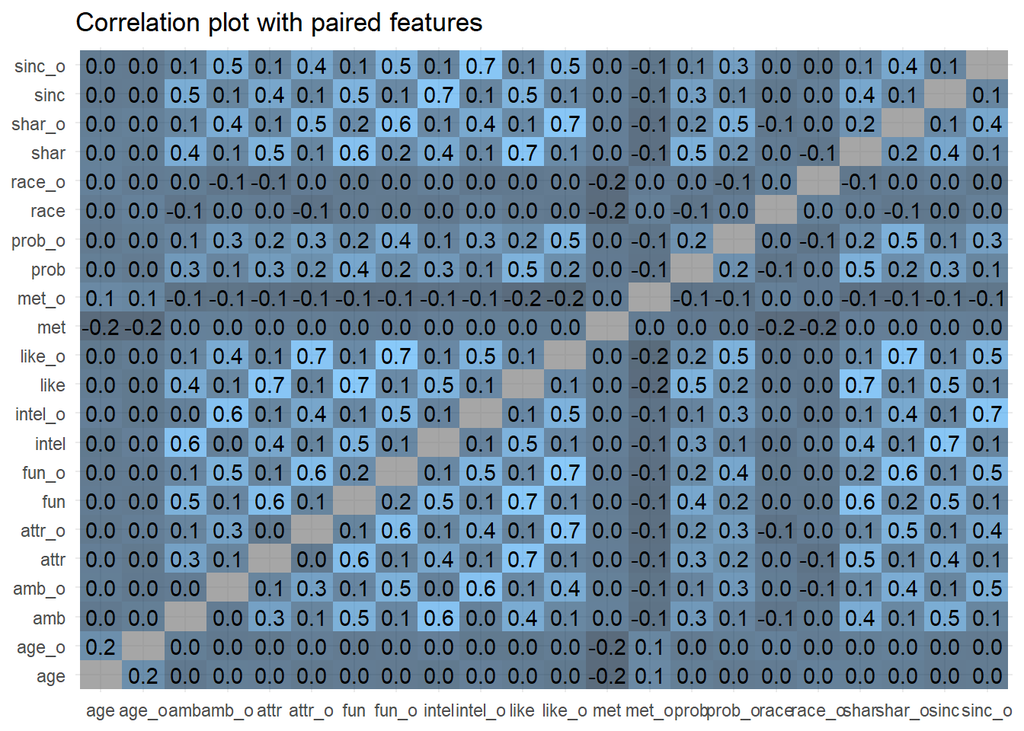

```r
cors <-
  df_slim_nona %>%
  select(where(is.numeric)) %>%
  corrr::correlate() %>%
  rename(col1 = rowname) %>%
  pivot_longer(
    -col1,
    names_to = 'col2',
    values_to = 'cor'
  )

gg_cors <-
  cors %>%
  ggplot() +
  aes(x = col1, y = col2) +
  geom_tile(aes(fill = cor), alpha = 0.7) +
  geom_text(aes(label = scales::number(cor, 0.1))) +
  theme_minimal() +
  guides(fill = FALSE) +
  labs(
    title = 'Correlation plot with paired features',
    x = NULL, y = NULL
  )
gg_cors
```

Can we differentiate solely based on these paired features? Also, I don’t think I need to split into train-test if we have a true holdout? Probably a bad call, but that’s why I’m an engineer and not a true DS.

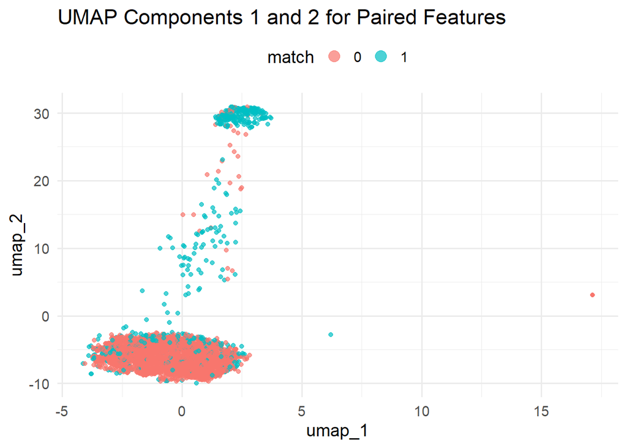

```r
# Use the nona data set for this cuz we don't like nas.
rec_umap <-
  recipe(match ~ ., data = df_slim_nona) %>%
  embed::step_umap(all_predictors(), outcome = vars(match), num_comp = 2)

juiced_umap <-
  rec_umap %>%
  prep() %>%
  juice()

gg_umap <-
  juiced_umap %>%
  ggplot() +
  aes(x = umap_1, umap_2) +
  geom_point(aes(color = match), alpha = 0.7) +
  theme_minimal(base_size = 14) +
  guides(
    color = guide_legend(override.aes = list(size = 4))
  ) +
  theme(legend.position = 'top') +
  labs(
    title = 'UMAP Components 1 and 2 for Paired Features'
  )
gg_umap
```

lol at the outlier in the umap plot above.

```r
rec <-
  recipe(match ~ ., data = df_slim) %>%
  # One of these steps (probably near zero variance?) is causing a column to be dropped in rand forest, which sometimes raises a warning
  # step_nzv(all_numeric_predictors()) %>%
  step_zv(all_numeric_predictors()) %>%
  # step_lincomb(all_numeric_predictors()) %>%
  # Impute at the end?
  step_impute_knn(all_numeric_predictors()) %>%
  step_downsample(all_outcomes())

# Just checking that it works.
rec %>%
  prep() %>%
  juice()
```

```
## # A tibble: 1,992 x 23
##      age   amb  attr   fun intel  like   met  prob  race  shar  sinc age_o amb_o
##    <dbl> <dbl> <dbl> <dbl> <dbl> <dbl> <dbl> <dbl> <dbl> <dbl> <dbl> <dbl> <dbl>
##  1    30   5       6     6     5   6     2     4       4   4     6      23    10
##  2    29   5.4     6     3     5   5     2     3       2   5     5.6    28     6
##  3    36   5       7     5     7   5     0     2       2   4.8   7      33     8
##  4    23  10       7     8    10   7     2     5       2   7     8      27     6
##  5    24   6       7     5     5   3     0     2       4   1     8      25     3
##  6    27   8       6     8     8   8     1.2   8       4   8     7      27     6
##  7    23   5       8     9     7   8     2     1       2   4     7      27     7
##  8    23   9       3     5     9   6     2     7       4   2    10      21     7
##  9    26   6       2     6     7   6.4   0     6.4     2   6     8      29    10
## 10    23   6       6     6     6   4     0     6       4   6     6      26     7
## # ... with 1,982 more rows, and 10 more variables: attr_o <dbl>, fun_o <dbl>,
## #   intel_o <dbl>, like_o <dbl>, met_o <dbl>, prob_o <dbl>, race_o <dbl>,
## #   shar_o <dbl>, sinc_o <dbl>, match <fct>
```

I’m intentionally picking methods that are relatively different and don’t have a lot of stuff to tune.